# What's the Current Best Computer Science Job?

## Introduction

As a first-year Computer Science (CS) major, I want to know more about the current CS job scheme. This project analyzes recent CS job salary data to figure out the best CS jobs to pursue. In context, I define success based on 1) popularity, how common the job is, and 2) salary, how much the job pays. I use the 'AI, ML, Data Science Salary (2020- 2025)' dataset from Kaggle, which contains salary and Employment trends in AI, ML, and Data Science from the past 5 years.

## Set Up

Before I manipulate the dataset, I want to set up my code, filter out irrelevant data, and visualize the raw data.

### Import Modules

I import the necessary modules.

```python
#library used for creating a dataframe from the given file
import pandas as pd
#library for keeping count of values
from collections import Counter
#library used for basic math functions
import math
#library used to create weighted vectors and sums
import numpy as np
#library used to create visual graph representations
import matplotlib.pyplot as plt
#library used for linear regression
from sklearn.linear_model import LinearRegression
#library used to compute r^2 for linear regression
from sklearn.metrics import r2_score
#library used for k-means clustering
from sklearn.cluster import KMeans
#library used to produce visually-appealing scatter plots
import seaborn as sns
```

### Filter Dataset

**Description**: The dataset is large, and I only need to focus on jobs relevant to me when I graduate. I filter the dataset to only include full-time entry-level employees from the US. The dataset contains many different jobs, so for grouping purposes, I create a 'general_jobs_title' column to specify the general job for each specific job (ex. 'Engineer' for 'Software Engineer').

**Analysis**: The dataset includes the following data: work year, experience level, employment type, job title, salary, salary currency, salary in USD, employee residence, remote ratio, company location, and company size. Since I'm focusing on full-time US employees, I don't have to worry about converting salaries to USD.

```python
#load dataset
df = pd.read_csv(r'salaries.csv')

#only include full-time entry-level US employees
df = df[(df["employment_type"] == "FT") & (df["employee_residence"] == "US") & (df["experience_level"] == "EN")]

#create new column for general jobs
df["general_job_title"] = df["job_title"].apply(lambda x: x.split(' ')[-1].strip())

#output results
print(df.head(10))
```

```
    work_year experience_level employment_type           job_title  salary  \
5        2025               EN              FT        Data Analyst   82000
6        2025               EN              FT        Data Analyst   44000
28       2025               EN              FT  Research Scientist  266000
29       2025               EN              FT  Research Scientist  177688
30       2025               EN              FT  Research Scientist  358000
31       2025               EN              FT  Research Scientist  187040
32       2025               EN              FT  Research Scientist  358000
33       2025               EN              FT  Research Scientist  187040
34       2025               EN              FT  Research Scientist  266000
35       2025               EN              FT  Research Scientist  177688

   salary_currency  salary_in_usd employee_residence  remote_ratio  \
5              USD          82000                 US             0
6              USD          44000                 US             0
```

[output cut: 20 more lines]

### Visualize Raw Data

**Description**: Before I do anything, I want to visualize the data and see where jobs lie based on popularity and salary. I create a function **k_means_clustering()** that takes in 2 features and the number of desired clusters, applies k-mean clustering based on those features, and outputs the results on a scatter plot. I run the function using salary and popularity as features with 3 clusters.

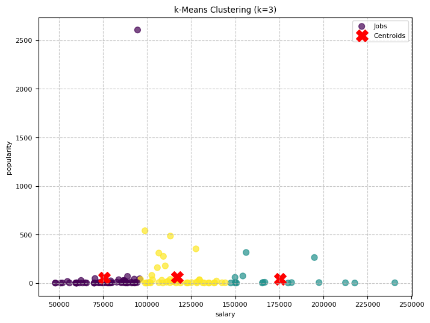

```python
def k_means_clustering(feature1, feature2, k):
    """ Applies k-means clustering to dataset

    Args:
        feature1 (String): first feature k-means clustering will base on
        feature2 (String): second feature k-means clustering will base on
        k (integer): number of clusters
    """

    #get counts for each specific job
    counter = Counter(df['job_title'])
    sorted_counter = dict(sorted(counter.items()))

    #create a temporary data frame to store the popularity and mean salary for each job
    temp_df = pd.DataFrame(columns=['popularity', 'salary'])
    temp_df['popularity'] = sorted_counter.values()
    temp_df['salary'] = df.groupby("job_title")["salary"].mean().values

    #select features
    X = temp_df[[feature1, feature2]].values

    #store labels and centroids
    kmeans = KMeans(n_clusters=k, init='k-means++', random_state=42, n_init='auto')
    labels = kmeans.fit_predict(X)
    centroids = kmeans.cluster_centers_

    #output results (scatter plot)
    plt.figure(figsize=(8, 6))
    plt.scatter(X[:, 0], X[:, 1], c=labels, cmap='viridis', s=50, alpha=0.7, label="Jobs")
    plt.scatter(centroids[:, 0], centroids[:, 1], c='red', marker='X', s=200, label='Centroids')
    plt.xlabel(f"{feature1}")
    plt.ylabel(f"{feature2}")
    plt.title(f"k‑Means Clustering (k={k})")
    plt.legend()
    plt.grid(True, linestyle="--", alpha=0.7)
    plt.show()

#apply k-means clustering on salary and popularity with 3 clusters
k_means_clustering('salary', 'popularity', 3)
```

## Popularity

Firstly, I want to know which jobs are the most popular. Popular jobs tend to offer more job security, resources, networking opportunities, and benefits. I want to pursue a job with a high likelihood of still being in the market a few years later.

### Popularity Summary Statistics

**Description**: I create a function **popularity_summary_statistics()** that takes in a job column and outputs the top 10 most common jobs in that column via text, bar graphs, and pie charts. I run this function for both general and specific jobs.

**Analysis**: Based on the text output, Analysts, Engineers, and Scientists are the most common general CS jobs from the last 5 years. Data Analysts, Analysts, and Data Scientists are the most common specific CS jobs from the last 5 years. Based on the bar graphs and pie charts, I can see that there have been a large number of Analysts in recent years; Analysts and Data Analysts are the most popular in their respective groups by a large margin. However, the top 3 general jobs are significantly more popular than the rest, taking up the most area in the pie chart cumulatively and dominating the top 10 specific jobs. Therefore, I will explore these jobs deeper.

```
General Jobs:

10 most common jobs:
Analyst appears 3952 times
Engineer appears 1515 times
Scientist appears 826 times
Developer appears 108 times
Specialist appears 70 times
Manager appears 54 times
Associate appears 51 times
Consultant appears 42 times
Intelligence appears 24 times
Assistant appears 18 times
```

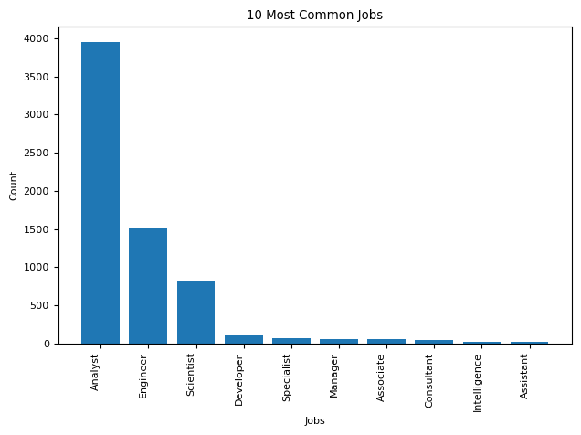

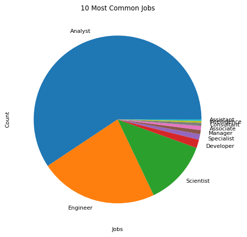

```
Specific Jobs:

10 most common jobs:
Data Analyst appears 2606 times
Analyst appears 540 times
Data Scientist appears 485 times
Software Engineer appears 353 times
Machine Learning Engineer appears 316 times
Data Engineer appears 310 times
Engineer appears 276 times
Research Scientist appears 264 times
Research Analyst appears 178 times
Business Intelligence Analyst appears 160 times
```

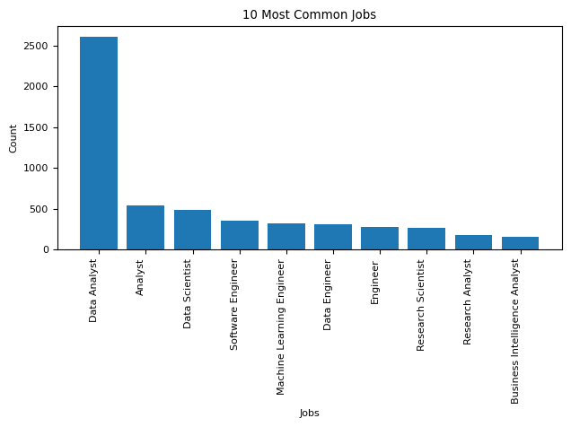

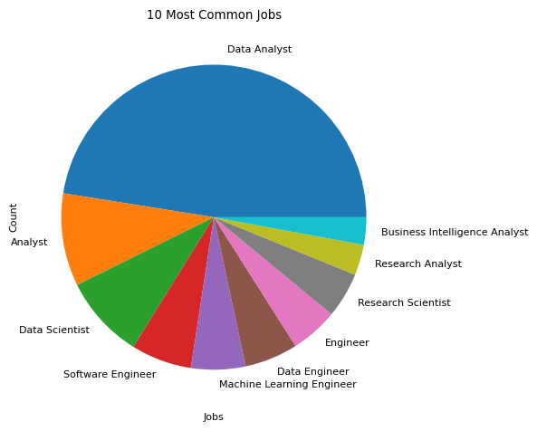

```python
def popularity_summary_statistics(job_column):
    """ Outputs popularity statistics for given job column via text, bar graphs, and pie charts

    Args:
        job_column (list): list of jobs

    Return:
        list: 10 most common jobs
    """
    #store the counts of each job
    counter = Counter(job_column)

    #store top 10 most common jobs
    top_10_common_jobs = counter.most_common(10)
    jobs = [x for x,_ in top_10_common_jobs]
    counts = [x for _,x in top_10_common_jobs]

    #output results (text)
    print("10 most common jobs: ")
    for job, count in top_10_common_jobs:
        print(f'{job} appears {count} times')
    print()

    #output results (bar graph)
    plt.bar(jobs,counts)
    plt.title("10 Most Common Jobs")
    plt.xticks(rotation=90, ha="right")
    plt.xlabel("Jobs")
    plt.ylabel("Count")
    plt.tight_layout()
    plt.show()

    #output results (pie chart)
    plt.pie(counts,labels=jobs)
    plt.title("10 Most Common Jobs")
    plt.xlabel("Jobs")
    plt.ylabel("Count")
    plt.tight_layout()
    plt.show()

    #return top 10 most common jobs
    return list(jobs)

#get popularity summary for general jobs
print("General Jobs: \n")
top_10_general_jobs = popularity_summary_statistics(df["general_job_title"])

#get popularity summary for specific jobs
print("Specific Jobs: \n")
top_10_specific_jobs = popularity_summary_statistics(df["job_title"])
```

### Salary

Secondly, I want to know which jobs have the highest salary. Higher-paying jobs tend to make more income, require a high level of education and technical skills, and contribute more meaningfully to society.

### Salary Summary Statistics

**Description**: I create a function **salary_summary_statistics()** that takes in a list of top jobs and a number representing the number of top jobs you want to analyze. The function outputs boxplots that give salary summary statistics. I ran this function for the top 3 general jobs (ie, Analyst, Engineer, Scientist).

**Analysis**: The boxplots all have a similar minimum salary, with the lowest around \$20,000 - \$30,000. However, the maximum varies a little more, with the highest non-outlier Analyst salary around \$200,000 and the highest Engineer and Scientist salaries closer to \$300,000. All jobs have a lot of outliers, with one Engineer outlier even going above \$700,000. In general, the summary statistics for Analyst salaries are lower than those for Engineers and Scientists. Its minimum, lower quartile, median, upper quartile, maximum, and most outliers are less than the other two. This is interesting since Analysts were the most popular general job. However, I don't see an obvious difference between the boxplots for engineers and scientists. Therefore, I will focus on these two jobs.

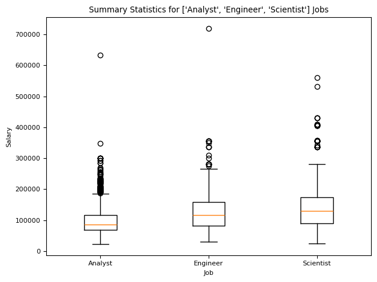

```python
def salary_summary_statistics(jobs, top_k):
    """ Gives summary statistics for top k given jobs via boxplots

    Args:
        jobs (list): top most common jobs
        top_k (int): how many top jobs you want to analyze
    """
    #stores the salaries for specific jobs
    job_salaries = []

    #get the salaries for the top k jobs
    for i in range(top_k):
        job_salaries.append(df[(df["general_job_title"] == jobs[i]) | (df["job_title"] == jobs[i])]["salary"])

    #output results on one boxplot
    plt.boxplot(job_salaries, tick_labels = jobs[:top_k])
    plt.title(f"Summary Statistics for {jobs[:3]} Jobs")
    plt.xlabel('Job')
    plt.ylabel('Salary')
    plt.tight_layout()
    plt.show()

#get salary statistics for top 3 general jobs
salary_summary_statistics(top_10_general_jobs, 3)
```

### Remove Outliers & Identify Highest Paying Jobs

**Analysis**: At first glance of the box plots, the means are very similar. Machine Learning Model Engineers only make around \$10,000 more than Research Scientists, Platform Engineers make around \$1000 less than Machine Learning Scientists, and a Machine Learning Engineer only makes around \$4000 more than an Applied Scientist. It's interesting to note that 3/6 jobs relate to Machine Learning. The box plots are also relatively similar. Therefore, I want to conduct further data analysis and predict future salary trends.

```
Top 3 Engineer Jobs:
Machine Learning Model Engineer gets paid an average of $180000.00
Platform Engineer gets paid an average of $165750.00
Machine Learning Engineer gets paid an average of $153775.62
```

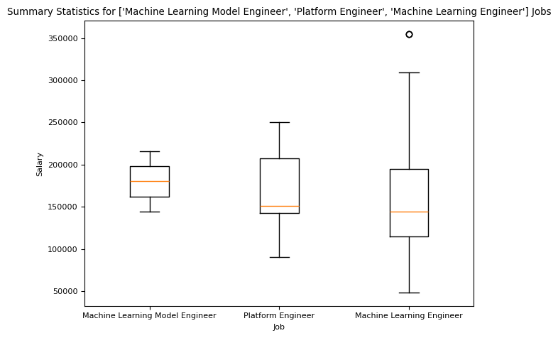

```
Top 3 Scientist Jobs:
Research Scientist gets paid an average of $170713.03
Machine Learning Scientist gets paid an average of $166816.67
Applied Scientist gets paid an average of $149884.00
```

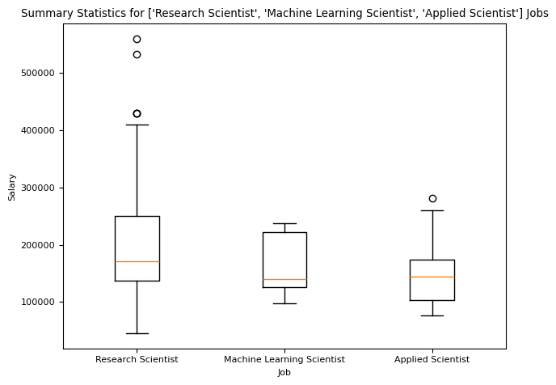

```python
def remove_outliers(column_name, df, lower, upper):
    """ Remove outliers from specified column in specified dataset using interquartile range

    Args:
        column_name (String): name of column you want to remove outliers from
        df (Data Frame): data frame from which you want to remove outliers
        lower (float): lower percent you don't want to include
        upper (float): upper percent you don't want to include

    Return:
        Data Frame: updated dataframe with outliers removed
    """
    #lower quartile
    Q1 = df[column_name].quantile(lower)
    #upper quartile
    Q3 = df[column_name].quantile(upper)
    #spread of middle (upper - lower) percent of data set
    range = Q3 - Q1
    #lower bound
    lower_bound = Q1 - 1.5 * range
    #upper bound
    upper_bound = Q3 + 1.5 * range
    #return dataframe without outliers
    return df[(df["salary"] >= lower_bound) & (df["salary"] <= upper_bound)]

def highest_paying_jobs(job, top_k):
    """ calculates the top k highest-paying specific jobs based on their overall salary mean.

    Args:
        job (String): general job you want to find the top k highest salary specific jobs
        top_k (int): number of highest-salary-specific jobs you want

    Return:
        list: top k jobs
    """
    #dataframe for specified job with removed outliers
    job_df = remove_outliers("salary", df[df["general_job_title"] == job], .25, .75)

    #average salary for each job
    salaries = job_df.groupby("job_title")["salary"].mean()

    #zip and highest paying jobs and their salaries
    highest_paying_jobs = zip(salaries.index, salaries.values)

    #sort highest paying jobs and their salaries
    highest_paying_jobs = sorted(highest_paying_jobs, key=lambda x: x[1], reverse=True)

    #output results for top k jobs
    print(f"Top {top_k} {job} Jobs: ")
    for job, salary in highest_paying_jobs[:top_k]:
        print(f"{job} gets paid an average of ${salary:.2f}")
    print()

    #return top k jobs
    return [x[0] for x in highest_paying_jobs[:top_k]]

#get top 3 engineers
top_3_engineers = highest_paying_jobs("Engineer", 3)

#output salary summary statistics for top 3 engineers
salary_summary_statistics(top_3_engineers, 3)

#get top 3 scientists
top_3_scientists = highest_paying_jobs("Scientist", 3)

#output salary summary statistics for top 3 scientists
salary_summary_statistics(top_3_scientists, 3)
```

### Salary Linear Regression

**Description**: I want to predict the future salaries for the top 3 paying Engineer and Scientist jobs using a linear regression model. To do so, I create a function **salary_linear_regression()** that takes in the top k jobs to fit a linear model on the salary data and create models for Engineers and Scientists. To remove outliers, I used the interquartile range.

**Analysis**: Despite getting rid of outliers, the R^2 values are really low, meaning that the line doesn't fit the data well. This shows that even within high-paying jobs, there's a lot of salary variation. It also shows that I'm using a complex data set. There are not as many data points as I would've liked, with some years only having a few points. This specific dataset seems to have the most data from 2024. However, we can still visualize salary trends over time. The salaries for both years increase over time. Engineers have an edge with a slightly higher slope of 11225.72, meaning that the top 3 Engineer salaries are increasing by an average of \$11,225.72 per year.

```
Slope: 11225.72, Intercept: -22565697.65, R²: 0.0151
```

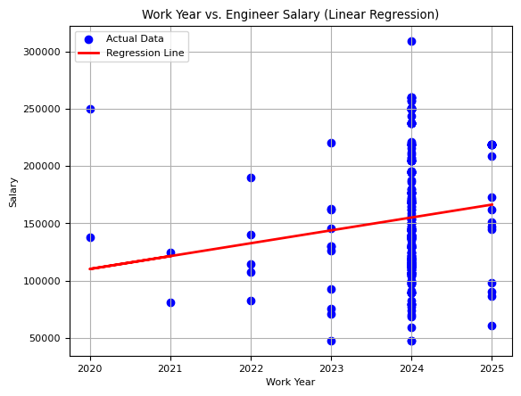

```
Slope: 11031.28, Intercept: -22150002.42, R²: 0.0049
```

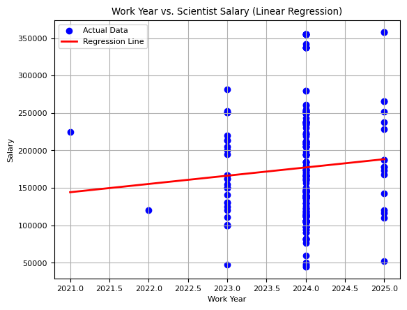

```python
def salary_linear_regression(top_k_jobs, lower, upper):
    """ fits a linear model on salary data

    Args:
        top_k_jobs (list): jobs you want to add to the linear regression model
        lower (float): lower percent you don't want to include
        upper (float): upper percent you don't want to include
    """
    #get the dataframe for the top k jobs
    top_k_df = remove_outliers("salary", df[df["job_title"].isin(top_k_jobs)], lower, upper)

    #store x and y values
    X = top_k_df["work_year"].values.reshape(-1, 1)
    Y = top_k_df["salary"].values

    #fit linear regression model
    model = LinearRegression()
    model.fit(X, Y)

    #get parameters
    slope = model.coef_[0]
    intercept = model.intercept_
    Y_pred = model.predict(X)
    r_squared = r2_score(Y, Y_pred)

    #output results
    print(f"Slope: {slope:.2f}, Intercept: {intercept:.2f}, R²: {r_squared:.4f}")

    #plot linear model
    plt.scatter(X, Y, color="blue", label="Actual Data")
    plt.plot(X, Y_pred, color="red", linewidth=2, label="Regression Line")
    plt.xlabel("Work Year")
    plt.ylabel("Salary")
    plt.title(f"Work Year vs. {top_k_jobs[0].split(" ")[-1]} Salary (Linear Regression)")
    plt.legend()
    plt.grid(True)
    plt.show()

#get linear model for top 3 engineers
salary_linear_regression(top_3_engineers, .25, .75)

#get linear model for top 3 scientists
salary_linear_regression(top_3_scientists, .25, .75)
```

### Weighted Sums

**Description**: The linear regression model was useful but maybe not the best metric for fitting the data. Therefore, I decided to find an alternate method to analyze the top 3 highest paying jobs: weighted sums. I created a function **weighted_sums()** that takes in the top k jobs, popularity weight, salary weight, and graph color to calculate and plot the weighted sums on histograms. I played around with different weight vectors, which control the importance of the popularity and salary. I tested 3 different scenarios: 1) popularity and salary are equally important 2) popularity is significantly more important, and 3) salary is significantly more important.

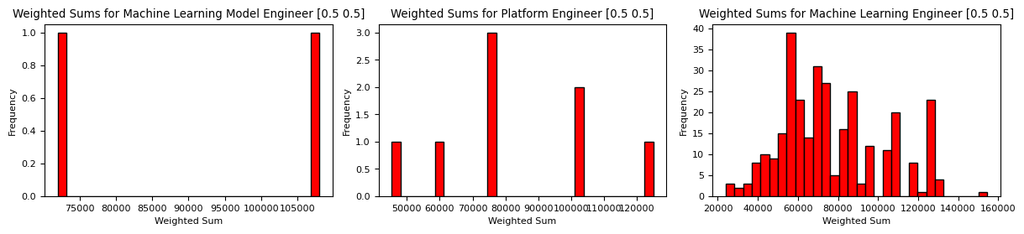

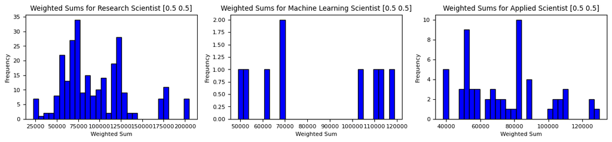

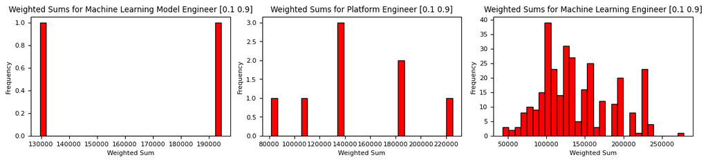

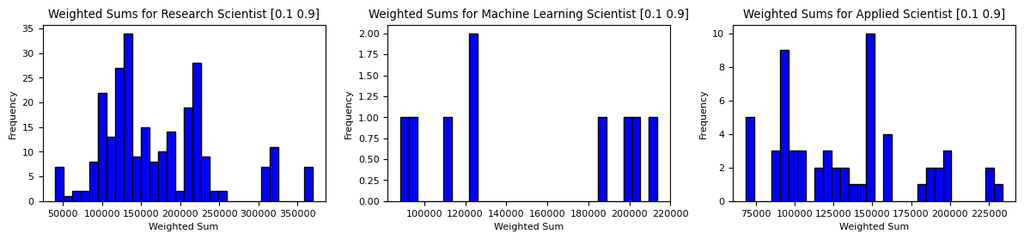

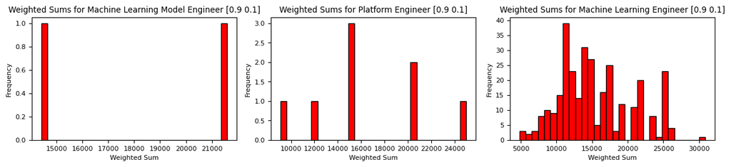

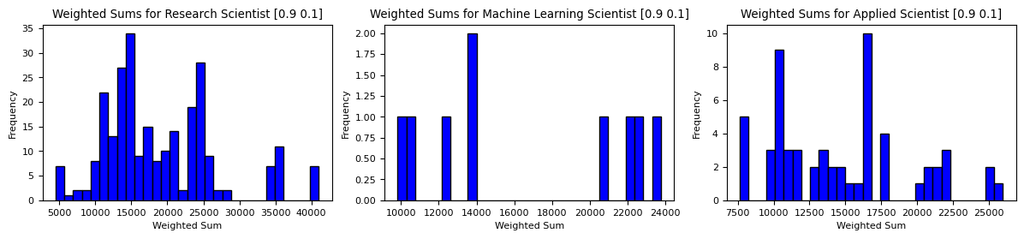

```python
def weighted_sums(top_k_jobs, popularity_weight, salary_weight, color):
    """ calculates weighted sums for top k jobs based on given weights and outputs on histograms

    Args:
        top_k_jobs (list): jobs you want to calculate weighted sum for
        popularity_weight (float): desired significance of popularity
        salary_weight (float): desired significance of salary
        color (String): desired graph color
    """

    #make subplot
    fig = plt.figure(figsize=(20,5))
    index = 1

    #create histograms for each job
    for job in top_k_jobs:
        #make new data set with removed outliers
        temp_df = remove_outliers("salary", df[df["job_title"] == job], .25, .75)
        popularity = [len(temp_df) / len(df) for i in range(len(temp_df))]
        salary = [temp_df["salary"].tolist()[i] for i in range(len(temp_df))]
        vectors = [popularity, salary]

        # Define vectors and weights
        vectors = np.array(vectors)
        weights = np.array([popularity_weight, salary_weight])

        # Calculate weighted sum
        weighted_sum = np.dot(weights, vectors)

        # Adding labels and title
        fig.add_subplot(2,5,index)
        plt.hist(weighted_sum, bins=30, color=color, edgecolor='black')
        plt.xlabel('Weighted Sum')
        plt.ylabel('Frequency')
        plt.title(f'Weighted Sums for {job} {weights}')
        index += 1

    # Display the plot
    plt.tight_layout()
    plt.show()

#display histogram of weighted sums with popularity weight = 0.5 and salary weight = 0.5
weighted_sums(top_3_engineers, 0.5,0.5,'red')
weighted_sums(top_3_scientists, 0.5,0.5,'blue')

#display histogram of weighted sums with popularity weight = 0.1 and salary weight = 0.9
weighted_sums(top_3_engineers, 0.1,0.9,'red')
weighted_sums(top_3_scientists, 0.1,0.9,'blue')

#display histogram of weighted sums with popularity weight = 0.9 and salary weight = 0.1
weighted_sums(top_3_engineers, 0.9,0.1,'red')
weighted_sums(top_3_scientists, 0.9,0.1,'blue')
```

### Summarize Results

**Analysis**: Based on previous text data, I know that Machine Learning Engineer appears 316 times, which is the 5th most common specific job, and gets paid an average of \$153,775.62 annually. Based on the box plot, they tend to make around \$100,000 - \$200,000 annually. Based on the linear regression model, their salary is expected to increase by around \$1166.33 per year. This means that by the time I graduate (2028), as a machine learning engineer, I would make an expected amount of 153,775.62 + 3(1166.33) = \$157,274.61 annually. Looking back at the k-means-clustering done nin the set up, the Machine Learning Engineer falls around the third cluster, but it's near the border between the second and third cluster. This is exactly what I was aiming for.

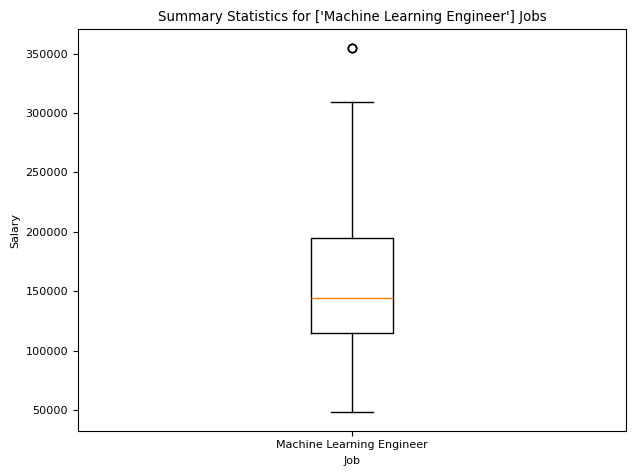

```
Slope: 1166.33, Intercept: -2221553.97, R²: 0.0004
```

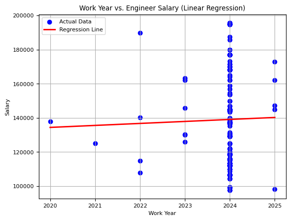

```python
salary_summary_statistics(['Machine Learning Engineer'], 1)
salary_linear_regression(['Machine Learning Engineer'], .4, .6)
```

### Additional Statistics

**Description**: Now that I have the best job based on both popularity and salary, I want to see what the specific job scheme for Machine Learning Engineers looks like. I created scatterplots to show the correlation between salary and both company size and remote ratio.

**Analysis**: The scatterplots show that Machine Learning Engineers most commonly work in-person at medium-sized companies. Instances under these conditions also tend to receive the highest salaries. In the future, I will try to aim for this sort of environment.

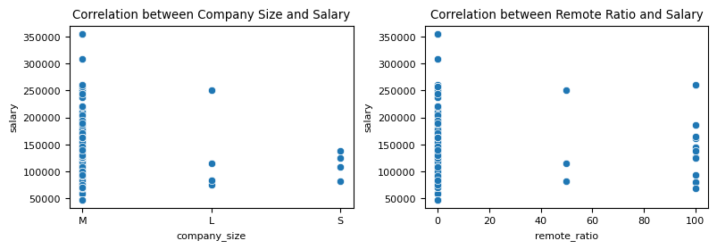

```python
#make sub plot
fig = plt.figure(figsize=(20,5))

#scatter plot for company size vs salary
fig.add_subplot(fig.add_subplot(2,5,1))
sns.scatterplot(data=df[df["job_title"] == 'Machine Learning Engineer'], x='company_size', y='salary')
plt.title("Correlation between Company Size and Salary")

#scatter plot for remote ratio and salary
fig.add_subplot(fig.add_subplot(2,5,2))
sns.scatterplot(data=df[df["job_title"] == 'Machine Learning Engineer'], x='remote_ratio', y='salary')
plt.title("Correlation between Remote Ratio and Salary")

#output results (scatter plot)
plt.tight_layout()
plt.show()
```

## Reflection

### Discussion

This project utilized many skills covered in this course. I gained a deeper understanding of analyzing and filtering data, using arrays, producing graphs and linear regression models, and implementing k-mean clustering. I learned how difficult it can be to conduct independent research in the real world since you are given no guidelines on how to begin or key to check your work. I also learned how effective the techniques I used are in differet contexts: arrays can be used to make quick calculations for large numerical sets of data, graphs can reveal new things about data that might not show from textual data alone, regression models can give insight to recent and future trends, and k-mean clustering can break data into related chunks. One challenge was knowing which techniques to use in different contexts. Many times, I tried to use a certain graph or algorithm, but it ended up being irrelevant to my goal. The solution for this was to solidify my goal. Once I knew that I was trying to find the most optimal CS jobs based on popularity and salary, I could focus more on specific tasks. A second challenge was going above and beyond - it was difficult to come up with complex analyses and figure out how to analyze the data set in deep ways. A solution was trial and error: by trying many different things, I figured out what worked and what didn't and built off of previous results.

### Future Improvements

Set-up wise, improvements could be made by choosing a better dataset. While my chosen data set was complex, it had a lot of categorical data but very little numerical data. This meant that my analyses were limited. With more numerical statistics, I could perform deeper analyses and utilize more skills. Code-wise, improvements could include making a general class so that different users can find their optimal job regardless of their field. My current code is specifically tailored to my preferences.

## Sources

Dataset Link: https://www.kaggle.com/datasets/samithsachidanandan/the-global-ai-ml-data-science-salary-for-2025/data

MLA citation: Samith Chimminiyan. “The AI, ML, Data Science Salary (2020- 2025).” Kaggle.com, 2020, www.kaggle.com/datasets/samithsachidanandan/the-global-ai-ml-data-science-salary-for-2025/data. Accessed 10 Apr. 2025.

I pulled inspiration for weighted sums from the following paper: https://www.vldb.org/pvldb/vol16/p2377-chen.pdf

MLA citation: Chen, Zixuan, et al. “Why Not Yet: Fixing a Top-k Ranking That Is Not Fair to Individuals.” Proceedings of the VLDB Endowment, vol. 16, no. 9, May 2023, pp. 2377–2390, www.vldb.org/pvldb/vol16/p2377-chen.pdf, https://doi.org/10.14778/3598581.3598606. Accessed 10 Apr. 2025.

Various code snippets were utilized from all our course labs, particularly labs 5 and 11.